# Práctica Act 1.6 - Combinaciones lineales y validación

Rey Iván De La Fuente Chávez

# Instrucciones

Resuelve esta práctica usando principalmente `Formulario_examen/FormularioMultivariado.Rmd` como apoyo.

- No consultes la Actividad 1.6 original mientras la resuelves.
- Escribe el código necesario debajo de cada inciso.
- Interpreta brevemente cuando se solicite.
- Cuando termines, haz Knit a HTML y sube el `.Rmd` y el `.html` al repositorio.

**Valor total: 100 puntos.**

# Problema 1 - Covarianza muestral con matrices (20 puntos)

Considera la matriz de datos

$$X=\begin{pmatrix}
1 & 3 & 7\\
2 & 1 & 4\\
4 & 2 & 8\\
5 & 4 & 13\\
7 & 0 & 7
\end{pmatrix}.$$

Cada fila es una observación y cada columna una variable.

## a) Crear `X` y obtener el vector de medias (5 puntos)

```r
# Escribe tu código aquí
X <- matrix(c(1, 3, 7,
              2, 1, 4,
              4, 2, 8,
              5, 4, 13,
              7, 0, 7),
            nrow = 5, byrow = TRUE)
```

## b) Calcular la matriz de covarianzas muestral con `cov()` (5 puntos)

```r
# Escribe tu código aquí
cov(X)
```

```
##       [,1]  [,2]  [,3]
## [1,]  5.70 -1.25  3.20
## [2,] -1.25  2.50  3.75
## [3,]  3.20  3.75 10.70
```

## c) Centrar los datos y comprobar manualmente que

$$S=\frac{1}{n-1}X_c^TX_c$$

(10 puntos)

```r
# Escribe tu código aquí
medias <- colMeans(X)
Xc <- sweep(X, 2, medias, "-")
n <- nrow(X)
S <- t(Xc) %*% Xc / (n - 1)
S
```

```
##       [,1]  [,2]  [,3]
## [1,]  5.70 -1.25  3.20
## [2,] -1.25  2.50  3.75
## [3,]  3.20  3.75 10.70
```

# Problema 2 - Combinaciones lineales (25 puntos)

Define

$$b=(1,1,1)^T$$

y

$$c=(2,-1,1)^T.$$

## a) Calcular las combinaciones `bX` y `cX` para cada observación (5 puntos)

```r
# Escribe tu código aquí
b <- t(matrix(c(1, 1, 1),
            nrow = 1, byrow = TRUE))

c <- t(matrix(c(2, -1, 1),
              nrow = 1, byrow = TRUE))

bX <- X %*% b
cX <- X %*% c
```

## b) Calcular las medias de ambas combinaciones mediante las fórmulas matriciales (5 puntos)

Usa:

$$E(b^TX)=b^T\bar X$$

$$E(c^TX)=c^T\bar X$$

```r
# Escribe tu código aquí
t(b) %*% medias
```

```
##      [,1]
## [1,] 13.6
```

```r
t(c) %*% medias
```

```
##      [,1]
## [1,] 13.4
```

## c) Calcular

$$Var(b^TX),\qquad Var(c^TX),\qquad
Cov(b^TX,c^TX)$$

mediante fórmulas matriciales (10 puntos)

```r
# Escribe tu código aquí
t(b) %*% S %*% b
```

```
##      [,1]
## [1,] 30.3
```

```r
t(c) %*% S %*% c
```

```
##      [,1]
## [1,] 46.3
```

```r
t(b) %*% S %*% c
```

```
##       [,1]
## [1,] 27.95
```

## d) Interpretar la covarianza entre ambas combinaciones (5 puntos)

Escribe tu respuesta aquí: la covarianza es de 27 lo que indica que las variables estan correlacionadas y no son independientes

# Problema 3 - Determinante, valores propios y dependencia lineal (20 puntos)

Usa la matriz de covarianzas `S` del Problema 1.

## a) Calcular el determinante de `S` y la varianza generalizada (5 puntos)

```r
# Escribe tu código aquí
det(S)
```

```
## [1] 0
```

## b) Obtener valores y vectores propios de `S` (5 puntos)

```r
# Escribe tu código aquí
eigen_S <- eigen(S)
eigen_S$values
```

```
## [1] 1.308008e+01 5.819917e+00 1.421085e-14
```

```r
eigen_S$vectors
```

```
##           [,1]       [,2]       [,3]
## [1,] 0.3421794  0.8463135  0.4082483
## [2,] 0.2777355 -0.5061584  0.8164966
## [3,] 0.8976504 -0.1660032 -0.4082483
```

```r
prod(eigen_S$values)
```

```
## [1] 1.081801e-12
```

## c) Revisar si existe un valor propio cercano a cero e interpretar qué significa (4 puntos)

Escribe tu respuesta aquí: El tercer valor propio esta muy cercano a 0, lo que indica que la varianza es aproximadamente 0 en esa dirección por lo que es una fuerte señal de que aunque los datos estan en R^3 realemente se podrían representar en R^2

## d) Verificar en los datos la relación lineal

$$X_3-X_1-2X_2=0$$

para todas las observaciones (3 puntos)

```r
# Escribe tu código aquí
0.4082483*X[,1] + 0.8164966*X[,2] + -0.4082483*X[,3]
```

```
## [1] 0 0 0 0 0
```

## e) Comprobar que el producto de los valores propios coincide aproximadamente con `det(S)` (3 puntos)

```r
# Escribe tu código aquí
1.308008e+01 * 5.819917e+00 * 1.421085e-14
```

```
## [1] 1.081801e-12
```

```r
det(S)
```

```
## [1] 0
```

# Problema 4 - Prueba de Henze-Zirkler (15 puntos)

Usa los siguientes datos:

```r
M <- data.frame(
  X1 = c(8.7, 9.1, 9.4, 9.7, 9.9, 10.0, 10.2, 10.4, 10.6, 10.9, 11.1, 11.4),
  X2 = c(11.2, 10.1, 10.8, 9.6, 10.4, 9.8, 10.7, 9.4, 10.5, 10.0, 11.0, 9.9)
)

M
```

```
##      X1   X2
## 1   8.7 11.2
## 2   9.1 10.1
## 3   9.4 10.8
## 4   9.7  9.6
## 5   9.9 10.4
## 6  10.0  9.8
## 7  10.2 10.7
## 8  10.4  9.4
## 9  10.6 10.5
## 10 10.9 10.0
## 11 11.1 11.0
## 12 11.4  9.9
```

## a) Aplicar la prueba de Henze-Zirkler con `MVN::mvn()` (7 puntos)

```r
# Escribe tu código aquí
resultado_hz <- MVN::mvn(data = M, mvn_test = "hz")
resultado_hz
```

```
## $multivariate_normality
##            Test Statistic p.value     Method      MVN
## 1 Henze-Zirkler     0.166   0.949 asymptotic ✓ Normal
##
## $univariate_normality
##               Test Variable Statistic p.value Normality
## 1 Anderson-Darling       X1     0.094   0.996  ✓ Normal
## 2 Anderson-Darling       X2     0.170   0.910  ✓ Normal
##
## $descriptives
##   Variable  n   Mean Std.Dev Median Min  Max  25th   75th   Skew Kurtosis
## 1       X1 12 10.117   0.817  10.10 8.7 11.4 9.625 10.675 -0.116    2.113
## 2       X2 12 10.283   0.572  10.25 9.4 11.2 9.875 10.725  0.078    1.841
##
## $data
##      X1   X2
## 1   8.7 11.2
## 2   9.1 10.1
## 3   9.4 10.8
## 4   9.7  9.6
## 5   9.9 10.4
## 6  10.0  9.8
## 7  10.2 10.7
## 8  10.4  9.4
## 9  10.6 10.5
## 10 10.9 10.0
## 11 11.1 11.0
## 12 11.4  9.9
##
## $subset
## NULL
##
## $outlierMethod
## [1] "none"
##
## attr(,"class")
## [1] "mvn"
```

## b) Con $\alpha=0.05$, interpretar la prueba (5 puntos)

Indica claramente:

- $H_0$ Los datos siguen una distribución normal multivariada
- $H_1$ Los datos no siguen una distribución normal multivariada
- decisión usando el p-value La distribución es normal multivariada
- conclusión Todo es normal multivariado y univariado

Escribe tu respuesta aquí:

## c) Generar, si está disponible, una visualización asociada al resultado (3 puntos)

```r
# Escribe tu código aquí
plot(resultado_hz, type = "persp")
```

[interactive chart not shown]

# Problema 5 - Mahalanobis y contorno de probabilidad (20 puntos)

Se tienen datos de edad de automóviles y precio de venta en miles de dólares:

```r
edad <- c(1, 2, 3, 4, 5, 6, 7, 8, 10, 12)
precio <- c(24.0, 22.5, 21.0, 19.0, 17.8, 15.5, 13.5, 12.2, 8.5, 6.0)

Autos <- cbind(edad, precio)
Autos
```

```
##       edad precio
##  [1,]    1   24.0
##  [2,]    2   22.5
##  [3,]    3   21.0
##  [4,]    4   19.0
##  [5,]    5   17.8
##  [6,]    6   15.5
##  [7,]    7   13.5
##  [8,]    8   12.2
##  [9,]   10    8.5
## [10,]   12    6.0
```

## a) Crear un diagrama de dispersión y calcular la covarianza entre las dos variables (4 puntos)

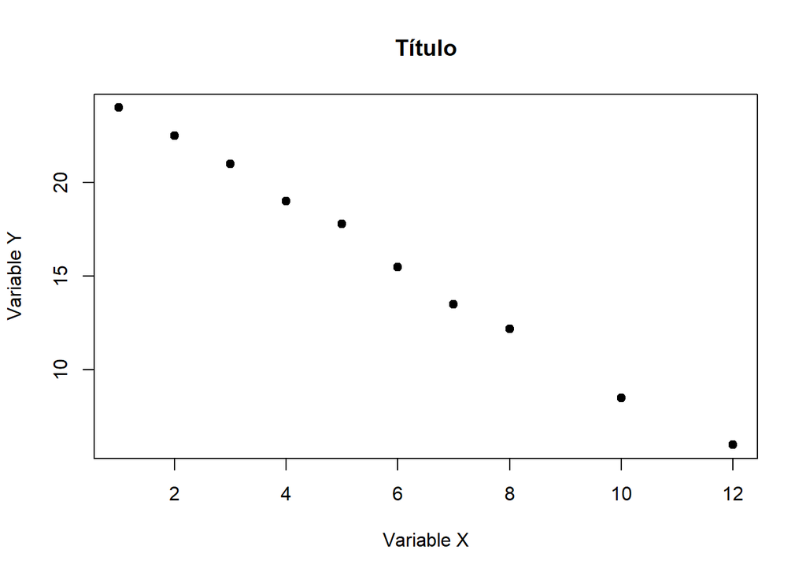

```r
# Escribe tu código aquí
plot(edad, precio,
     main = "Título",
     xlab = "Variable X",
     ylab = "Variable Y",
     pch = 19)
```

```r
cov(edad, precio)
```

```
## [1] -20.98889
```

Interpreta el signo de la covarianza: Estan correlacionadas negativamente

## b) Calcular las distancias de Mahalanobis al cuadrado (5 puntos)

```r
# Escribe tu código aquí
d2 <- mahalanobis(Autos, colMeans(Autos), cov(Autos))
d2
```

```
##  [1] 2.0073444 1.2087812 1.2837540 0.2822828 1.9591968 0.2533942 2.2250406
##  [8] 0.4459848 2.8884465 5.4457747
```

## c) Determinar qué observaciones se encuentran dentro del contorno de probabilidad del 50% (5 puntos)

Usa:

$$d_i^2\leq\chi^2_{2,0.50}$$

Calcula también la proporción de observaciones dentro.

```r
# Escribe tu código aquí
limite <- qchisq(0.5, df = ncol(Autos))
dentro <- d2 <= limite
sum(dentro)
```

```
## [1] 5
```

```r
mean(dentro)
```

```
## [1] 0.5
```

## d) Construir el diagrama Chi-cuadrado de las distancias de Mahalanobis (4 puntos)

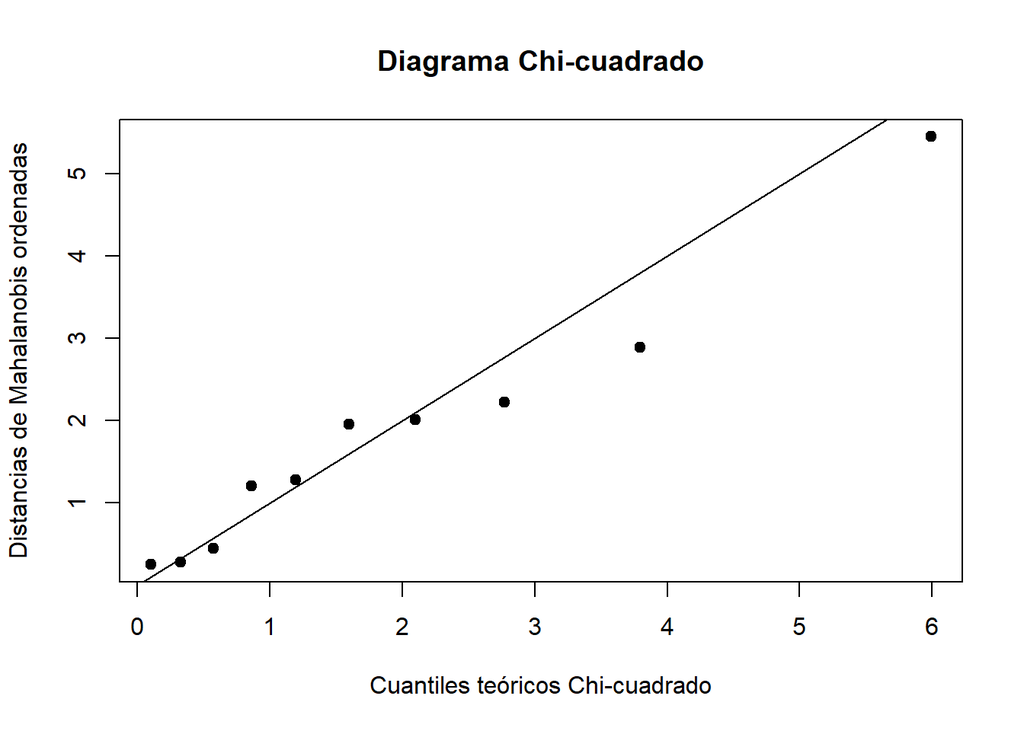

```r
# Escribe tu código aquí
n <- nrow(Autos)
p <- ncol(Autos)

d2_ordenadas <- sort(d2)
probabilidades <- ((1:n) - 0.5) / n
chi2 <- qchisq(probabilidades, df = p)

plot(chi2, d2_ordenadas,
     main = "Diagrama Chi-cuadrado",
     xlab = "Cuantiles teóricos Chi-cuadrado",
     ylab = "Distancias de Mahalanobis ordenadas",
     pch = 19)

abline(0, 1)
```

## e) Interpretar si los datos parecen aproximadamente compatibles con normalidad bivariada (2 puntos)

Escribe tu respuesta aquí: Los puntos se desvian un poco cuando los cuantiles son más elevados, sin embargo parece que si hay una normalidad bivariada

# Entrega

1. Haz Knit a HTML.
2. Guarda el `.Rmd` y el `.html`.
3. Súbelos al repositorio.
4. Avísame para revisar código, resultados e interpretación sobre 100 puntos.